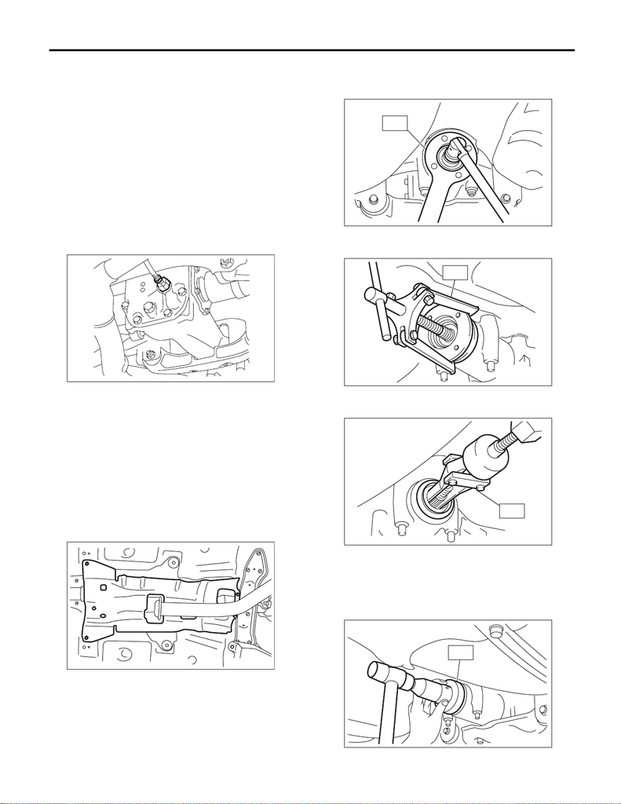

Rear Differential Front Oil Seal

DIFFERENTIALS

5. Rear Differential Front Oil

Seal

A: INSPECTION

Make sure that there is no leakage from front oil

seal portion. If there is any leakage replace the oil

seal and inspect the propeller shaft.

B: REPLACEMENT

1) Shift the select lever or gear shift lever to neutral.

2) Disconnect the ground cable from battery.

3) Release the parking brake.

4) Lift up the vehicle.

5) Disconnect the oil temperature sensor connec-

tor. (T-type (H5))

6) Drain differential gear oil. <Ref. to DI-16, RE-

PLACEMENT, Differential Gear Oil.>

7) Remove the rear exhaust pipe.

• Except for STI model

<Ref. to EX(w/o STI)-50, REMOVAL, Rear Exhaust

Pipe.>

• STI model

<Ref. to EX(STI)-12, REMOVAL, Rear Exhaust

Pipe.>

8) Remove the center exhaust cover.

9) Remove the propeller shaft. <Ref. to DS-12, RE-

MOVAL, Propeller Shaft.>

10) Check the initial torque and write it down.

11) Remove the self-locking nut while holding the

companion flange with ST.

ST 498427200 FLANGE WRENCH

12) Extract the companion flange using the ST.

ST 399703600 PULLER ASSY

13) Remove the oil seal using ST or screwdriver.

ST 398527700 PULLER ASSY

14) Using the ST, install the oil seal.

NOTE:

• Use a new oil seal.

• Apply differential gear oil to the oil seal lips.

ST 498447120 INSTALLER

(A) Oil temperature sensor connector

DI-00991

(A)

DI-00972

DI-00194

ST

DI-00196

ST

DI-00197

ST

DI-00292

ST

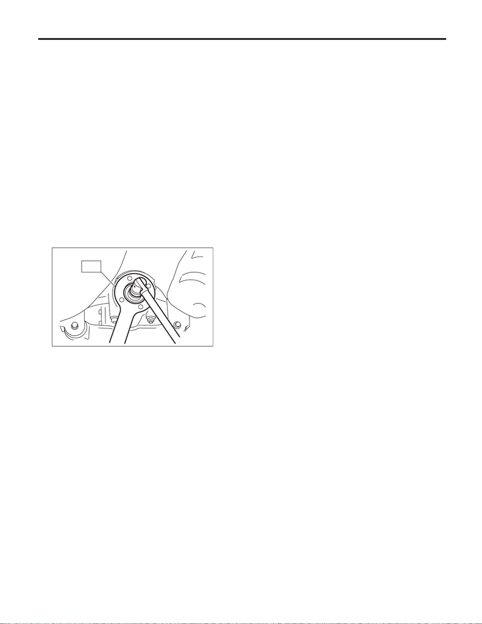

Rear Differential Front Oil Seal

DIFFERENTIALS

15) Install the companion flange.

NOTE:

Use a plastic hammer to install companion flange.

16) Tighten the self-locking nut to the specified

torque so that the initial torque of companion flange

becomes the same as that of before oil seal re-

placement.

NOTE:

• Use a new self-locking nut.

• Before installing the self-locking nut, apply the

seal material to the threads of the drive pinion shaft

and to the seating surface of the self-locking nut.

Seal material:

THREE BOND 1324 (Part No. 004403042) or

equivalent

Tightening torque:

167 — 196 N·m (17.0 — 20.0 kgf-m, 123.2 —

144.6 ft-lb)

ST 498427200 FLANGE WRENCH

17) Hereafter, perform assembly in the reverse or-

der of disassembly.

18) Fill differential gear oil. <Ref. to DI-16, RE-

PLACEMENT, Differential Gear Oil.>

DI-00194

ST